# Bike Sharing

Sahil kumar

February 18, 2018

Title : Analysis of Bike Sharing Dataset  
Name : Sahil kumar  
Email : sahilriders@gmail.com  
College : Institute of Engineering and Management , Kolkata

# Setting Working Directory

```r
setwd("G:/Intern - IIM Lucknow/Bike-Sharing-Dataset")
```

# Loading necessary packages

```r
library(psych)
library(car)
```

```r
library(corrgram)
library(ggplot2)
library("lattice", lib.loc="C:/Program Files/R/R-3.4.3/library")
```

# Reading Dataset

```r
df <- read.csv(paste("hour.csv",sep=""))
View(df)
```

# Describing Dataset

```r
describe(df)
```

```
##            vars     n    mean      sd  median trimmed     mad  min
## instant       1 17379 8690.00 5017.03 8690.00 8690.00 6441.90 1.00
## dteday*       2 17379  367.17  210.07  367.00  367.24  269.83 1.00
## season        3 17379    2.50    1.11    3.00    2.50    1.48 1.00
## yr            4 17379    0.50    0.50    1.00    0.50    0.00 0.00
## mnth          5 17379    6.54    3.44    7.00    6.54    4.45 1.00
## hr            6 17379   11.55    6.91   12.00   11.56    8.90 0.00
## holiday       7 17379    0.03    0.17    0.00    0.00    0.00 0.00
## weekday       8 17379    3.00    2.01    3.00    3.00    2.97 0.00
## workingday    9 17379    0.68    0.47    1.00    0.73    0.00 0.00
## weathersit   10 17379    1.43    0.64    1.00    1.30    0.00 1.00
## temp         11 17379    0.50    0.19    0.50    0.50    0.24 0.02
## atemp        12 17379    0.48    0.17    0.48    0.48    0.20 0.00
## hum          13 17379    0.63    0.19    0.63    0.63    0.22 0.00
## windspeed    14 17379    0.19    0.12    0.19    0.18    0.13 0.00
## casual       15 17379   35.68   49.31   17.00   25.13   23.72 0.00
## registered   16 17379  153.79  151.36  115.00  129.26  131.95 0.00
## cnt          17 17379  189.46  181.39  142.00  162.04  166.05 1.00
##                 max    range  skew kurtosis    se
## instant    17379.00 17378.00  0.00    -1.20 38.06
## dteday*      731.00   730.00  0.00    -1.19  1.59
## season         4.00     3.00 -0.01    -1.33  0.01
## yr             1.00     1.00 -0.01    -2.00  0.00
## mnth          12.00    11.00 -0.01    -1.20  0.03
## hr            23.00    23.00 -0.01    -1.20  0.05
## holiday        1.00     1.00  5.64    29.78  0.00
## weekday        6.00     6.00  0.00    -1.26  0.02
## workingday     1.00     1.00 -0.79    -1.38  0.00
## weathersit     4.00     3.00  1.23     0.35  0.00
## temp           1.00     0.98 -0.01    -0.94  0.00
## atemp          1.00     1.00 -0.09    -0.85  0.00
## hum            1.00     1.00 -0.11    -0.83  0.00
## windspeed      0.85     0.85  0.57     0.59  0.00
## casual       367.00   367.00  2.50     7.57  0.37
## registered   886.00   886.00  1.56     2.75  1.15
## cnt          977.00   976.00  1.28     1.42  1.38
```

```r
str(df)
```

```
## 'data.frame':    17379 obs. of  17 variables:
##  $ instant   : int  1 2 3 4 5 6 7 8 9 10 ...
##  $ dteday    : Factor w/ 731 levels "2011-01-01","2011-01-02",..: 1 1 1 1 1 1 1 1 1 1 ...
##  $ season    : int  1 1 1 1 1 1 1 1 1 1 ...
##  $ yr        : int  0 0 0 0 0 0 0 0 0 0 ...
##  $ mnth      : int  1 1 1 1 1 1 1 1 1 1 ...
##  $ hr        : int  0 1 2 3 4 5 6 7 8 9 ...
##  $ holiday   : int  0 0 0 0 0 0 0 0 0 0 ...
##  $ weekday   : int  6 6 6 6 6 6 6 6 6 6 ...
##  $ workingday: int  0 0 0 0 0 0 0 0 0 0 ...
##  $ weathersit: int  1 1 1 1 1 2 1 1 1 1 ...
##  $ temp      : num  0.24 0.22 0.22 0.24 0.24 0.24 0.22 0.2 0.24 0.32 ...
##  $ atemp     : num  0.288 0.273 0.273 0.288 0.288 ...
##  $ hum       : num  0.81 0.8 0.8 0.75 0.75 0.75 0.8 0.86 0.75 0.76 ...
##  $ windspeed : num  0 0 0 0 0 0.0896 0 0 0 0 ...
##  $ casual    : int  3 8 5 3 0 0 2 1 1 8 ...
##  $ registered: int  13 32 27 10 1 1 0 2 7 6 ...
##  $ cnt       : int  16 40 32 13 1 1 2 3 8 14 ...
```

*There are two types of customers :- 1. Casual 2. Registered

*Last 3 columns represents bike sharing among casual, registered and both customers.

# Season vs Bike Shared

**TABLE**

```r
attach(df)
aggregate(cbind(casual,registered,cnt)~season,data=df,mean)
```

```
##   season   casual registered      cnt
## 1      1 14.29090   96.82367 111.1146
## 2      2 46.16058  162.18349 208.3441
## 3      3 50.28714  185.72909 236.0162
## 4      4 30.66682  168.20203 198.8689
```

**BOXPLOTS**

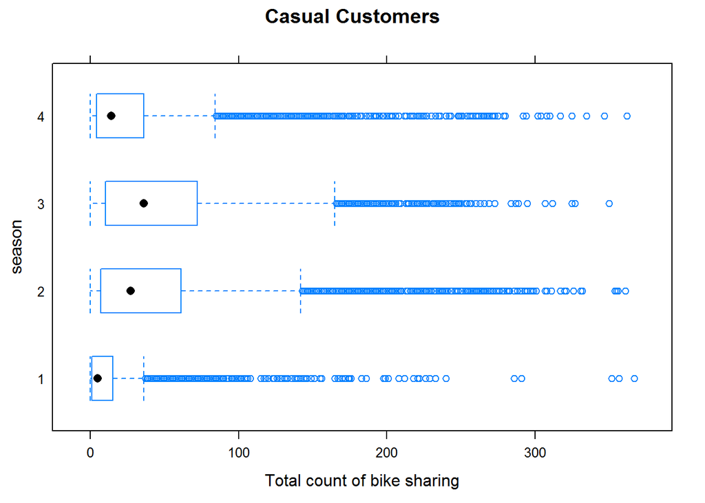

```r
par(mfrow=c(3,1))
bwplot(season~casual ,data=df,xlab = "Total count of bike sharing",main='Casual Customers')
```

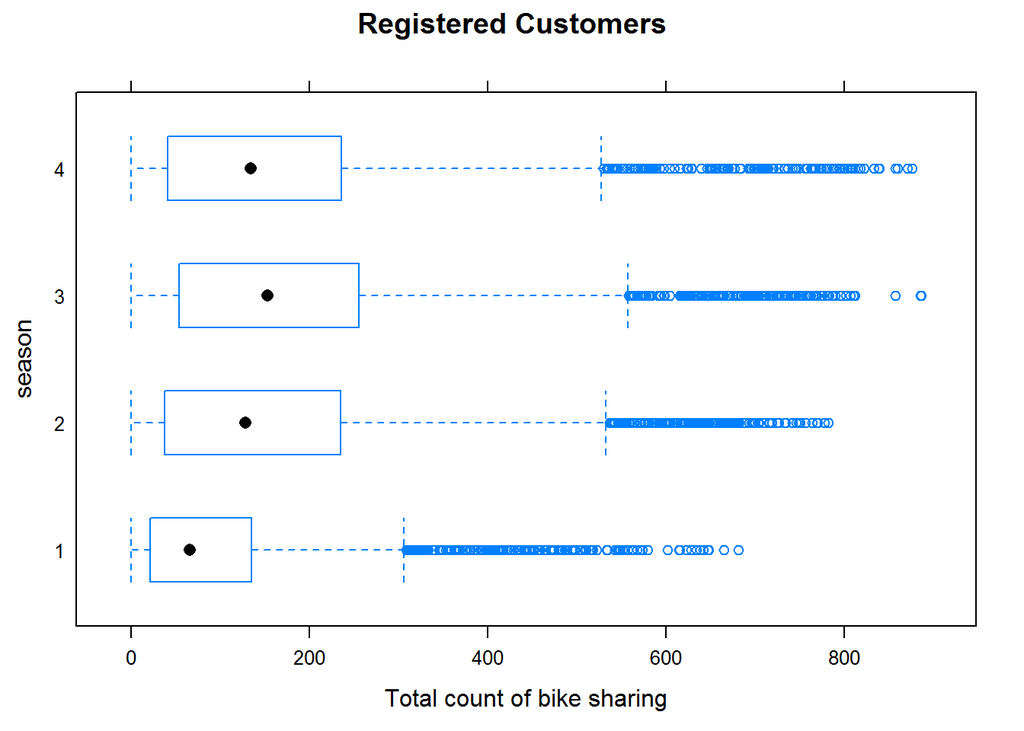

```r
bwplot(season~registered ,data=df,xlab = "Total count of bike sharing",main='Registered Customers')
```

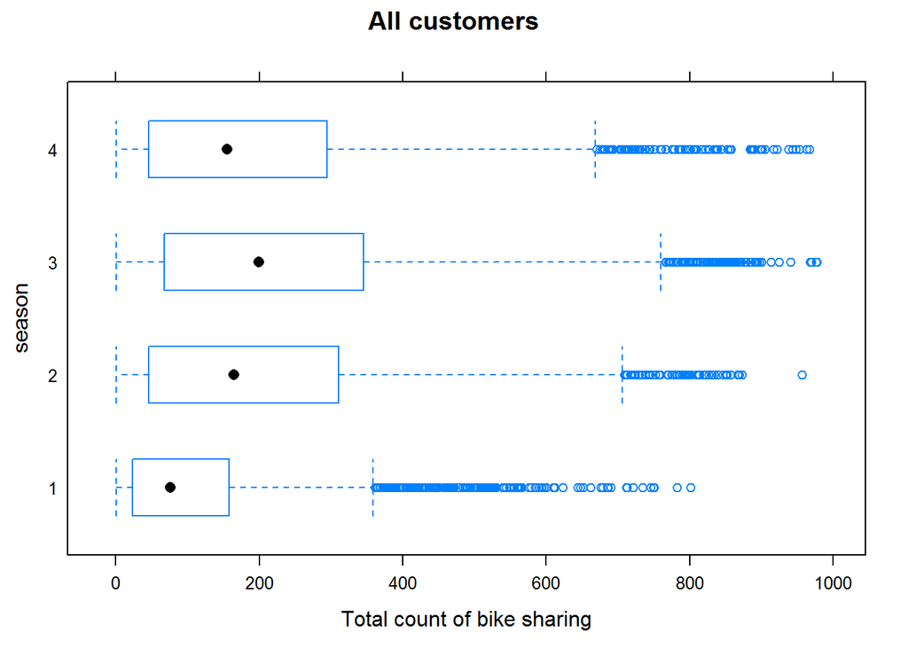

```r
bwplot(season~cnt ,data=df,xlab = "Total count of bike sharing",main='All customers')
```

**Inference :**

1. Maximum bike sharing is done in Season 3.
2. 2. Bike shared among registered users is more than casual users.

# Month vs Bike shared

**TABLE**

```r
aggregate(cbind(casual,registered,cnt)~mnth,data=df,mean)
```

```
##    mnth    casual registered       cnt
## 1     1  8.426872    85.9979  94.42477
## 2     2 11.158091   101.7069 112.86503
## 3     3 30.172437   125.2383 155.41073
## 4     4 42.311761   144.9492 187.26096
## 5     5 50.594758   172.3125 222.90726
## 6     6 51.323611   189.1917 240.51528
## 7     7 52.524866   179.2950 231.81989
## 8     8 48.840000   189.2576 238.09763
## 9     9 48.937370   191.8358 240.77314
## 10   10 41.185389   180.9731 222.15851
## 11   11 25.471816   151.8636 177.33542
## 12   12 14.627782   127.6757 142.30344
```

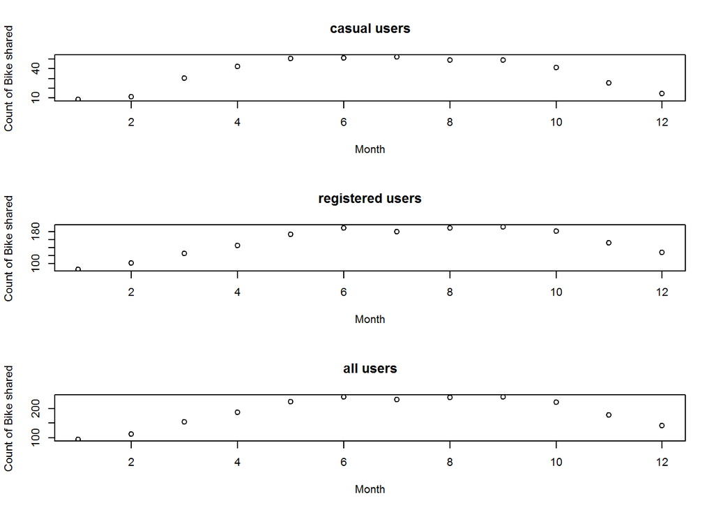

```r
par(mfrow=c(3,1))
plot(aggregate(casual~mnth ,data=df,mean),xlab='Month',ylab='Count of Bike shared',main='casual users')
plot(aggregate(registered~mnth ,data=df,mean),xlab='Month',ylab='Count of Bike shared',main='registered users')
plot(aggregate(cnt~mnth ,data=df,mean),xlab='Month',ylab='Count of Bike shared',main='all users')
```

**Inference:-**  
On an Average , most bike sharing happens between March to November month.  
**Hypothesis:-**  
Reason of low bike sharing in other months can be LOW TEMPERATURE.

# Hour vs Bike shared

**TABLE**

```r
aggregate(cbind(casual,registered,cnt)~hr,data=df,mean)
```

```
##    hr    casual registered        cnt
## 1   0 10.158402  43.739669  53.898072
## 2   1  6.504144  26.871547  33.375691
## 3   2  4.772028  18.097902  22.869930
## 4   3  2.715925   9.011478  11.727403
## 5   4  1.253945   5.098996   6.352941
## 6   5  1.411437  18.478382  19.889819
## 7   6  4.161379  71.882759  76.044138
## 8   7 11.055021 201.009629 212.064649
## 9   8 21.679505 337.331499 359.011004
## 10  9 30.891334 188.418157 219.309491
## 11 10 46.477304 127.191197 173.668501
## 12 11 59.540578 148.602476 208.143054
## 13 12 68.293956 185.021978 253.315934
## 14 13 72.308642 181.352538 253.661180
## 15 14 75.567901 165.381344 240.949246
## 16 15 74.905350 176.327846 251.233196
## 17 16 73.745205 238.238356 311.983562
## 18 17 74.273973 387.178082 461.452055
## 19 18 61.120879 364.390110 425.510989
## 20 19 48.770604 262.752747 311.523352
## 21 20 36.233516 189.796703 226.030220
## 22 21 28.255495 144.059066 172.314560
## 23 22 22.252747 109.082418 131.335165
## 24 23 15.199176  72.631868  87.831044
```

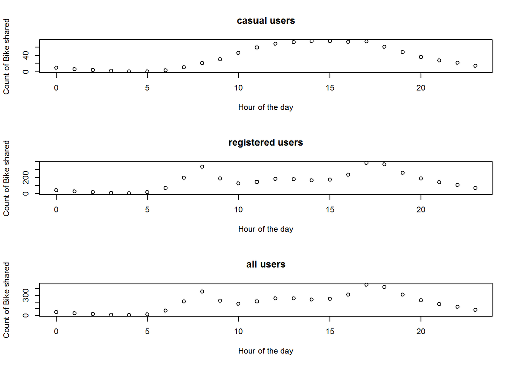

```r
par(mfrow=c(3,1))
plot(aggregate(casual~hr ,data=df,mean),xlab='Hour of the day',ylab='Count of Bike shared',main='casual users')
plot(aggregate(registered~hr ,data=df,mean),xlab='Hour of the day',ylab='Count of Bike shared',main='registered users')
plot(aggregate(cnt~hr ,data=df,mean),xlab='Hour of the day',ylab='Count of Bike shared',main='all users')
```

**Inference :-**  
1. For casual customers , bike sharing starts around 7am ,reaches its peak around 2pm then further decreases.  
2. In General , bike sharing reaches its peak around 8 am ,declines and again rises to reach its peak around 5pm.

**Hypothesis:**  
Bike sharing is more in morning and evening.  
Not in afternoon , maybe due to excess heat.

# EFFECT OF HOLIDAYS ON BIKE SHARING

**TABLE**

```r
mytable<-aggregate(cbind(casual,registered,cnt)~holiday ,data=df,mean)
mytable
```

```
##   holiday   casual registered      cnt
## 1       0 35.40838   155.0202 190.4286
## 2       1 44.71800   112.1520 156.8700
```

**BARCHARTS**

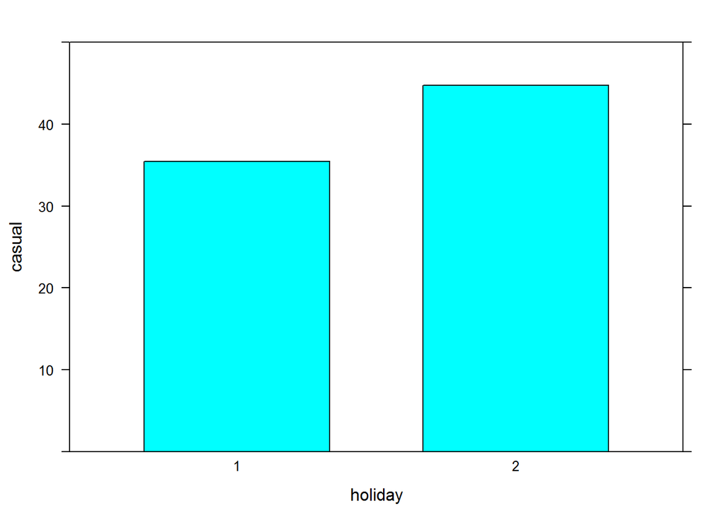

```r
par(mfrow=c(1,3))
barchart(casual~holiday,data=mytable,horizontal=FALSE,ylim=c(0,50))
```

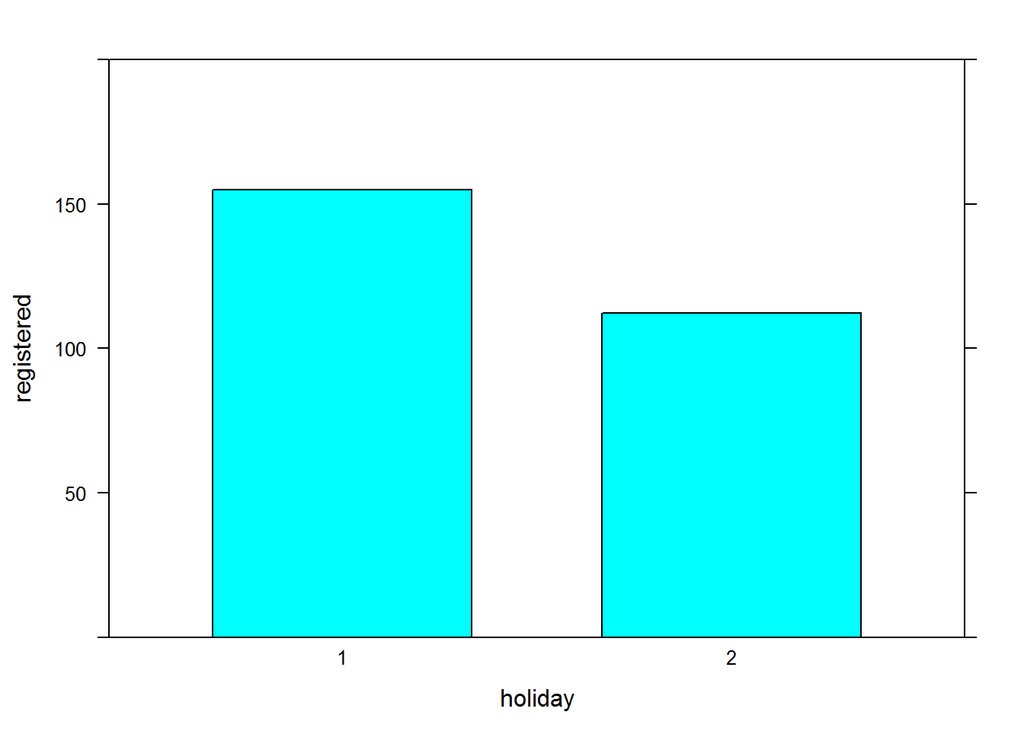

```r
barchart(registered~holiday,data=mytable,horizontal=FALSE,ylim=c(0,200))
```

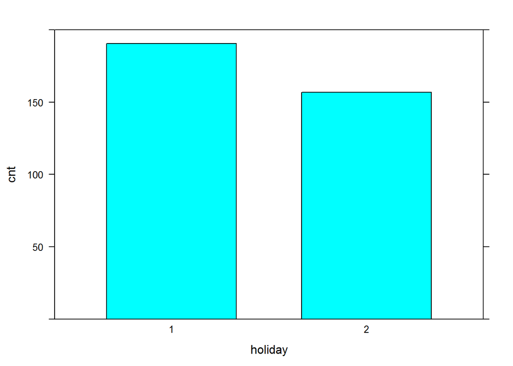

```r
barchart(cnt~holiday,data=mytable,horizontal=FALSE,ylim=c(0,200))
```

# EFFECT OF WEATHER SITUATION ON TOTAL BIKE SHARING

**TABLE**

```r
wsittable<-aggregate(cnt~weathersit ,data=df,mean)
wsittable
```

```
##   weathersit       cnt
## 1          1 204.86927
## 2          2 175.16549
## 3          3 111.57928
## 4          4  74.33333
```

**BOXPLOTS**

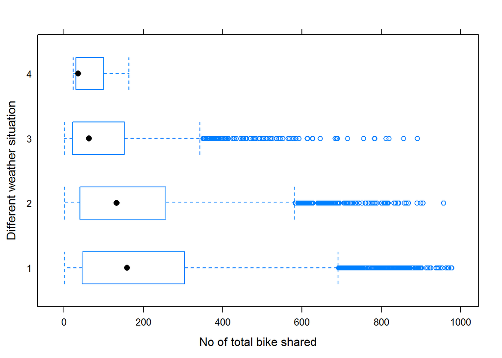

```r
bwplot(weathersit~cnt,data=df,xlab ="No of total bike shared",ylab="Different weather situation",main="")
```

Weather Situtation 1 is highly suitable for bike sharing.

# Scatterplot of temp vs total bike sharing

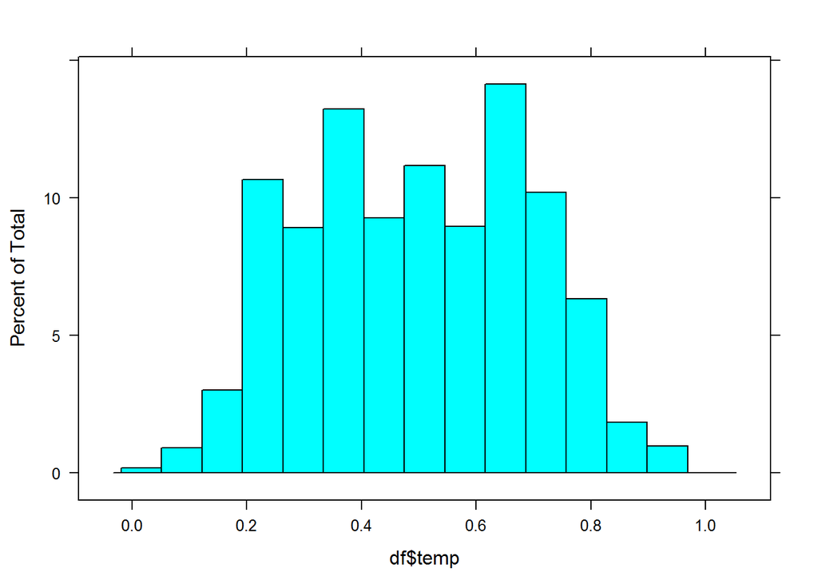

```r
histogram(df$temp)
```

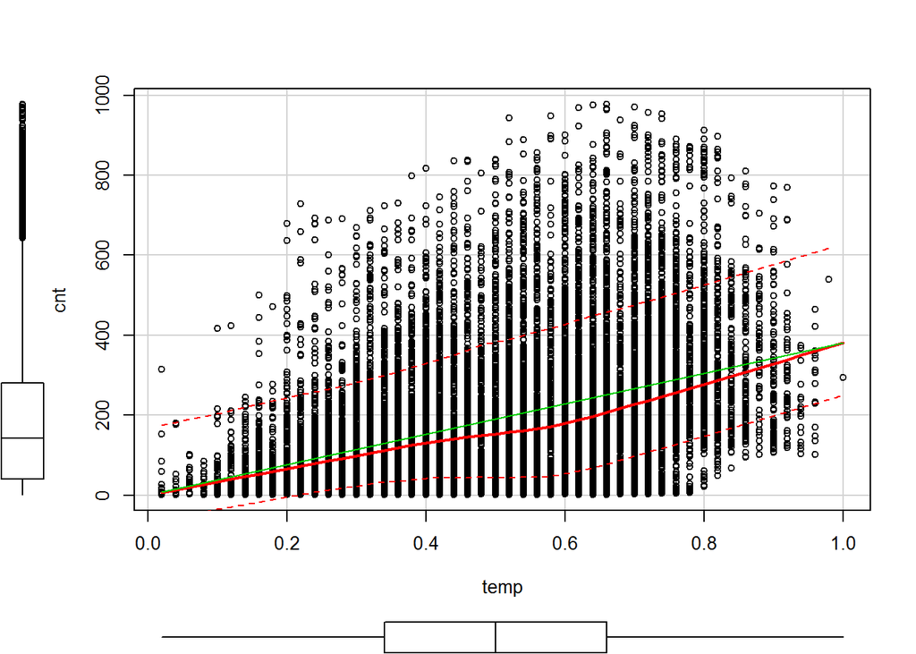

```r
scatterplot(cnt~temp,data=df)
```

# Humidity

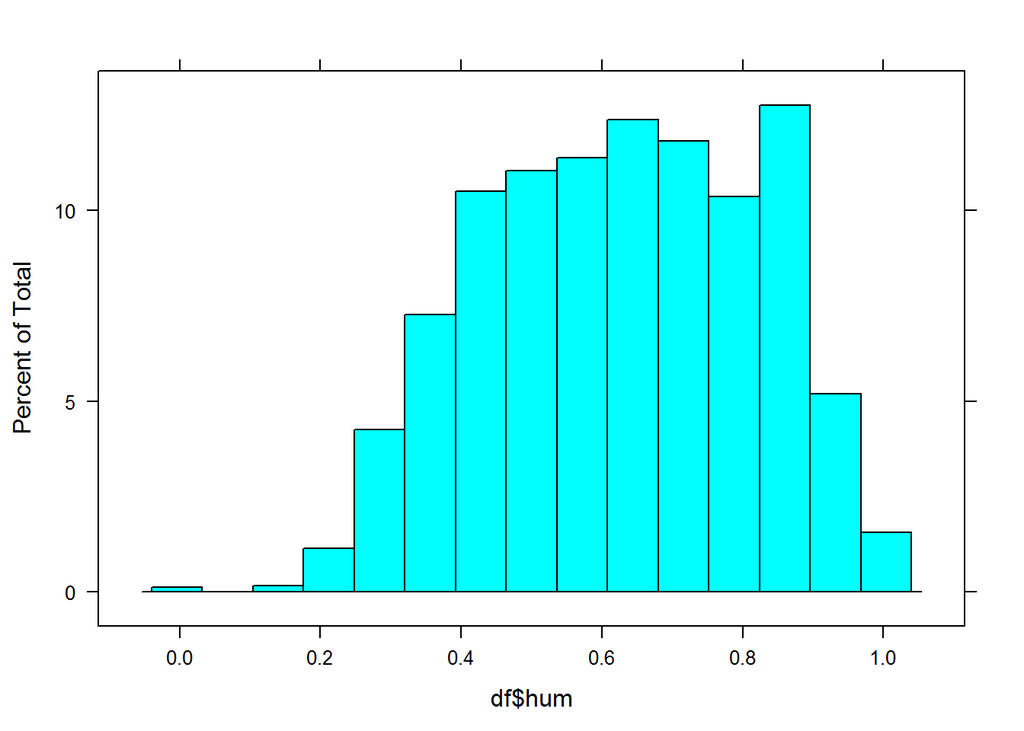

```r
histogram(df$hum)
```

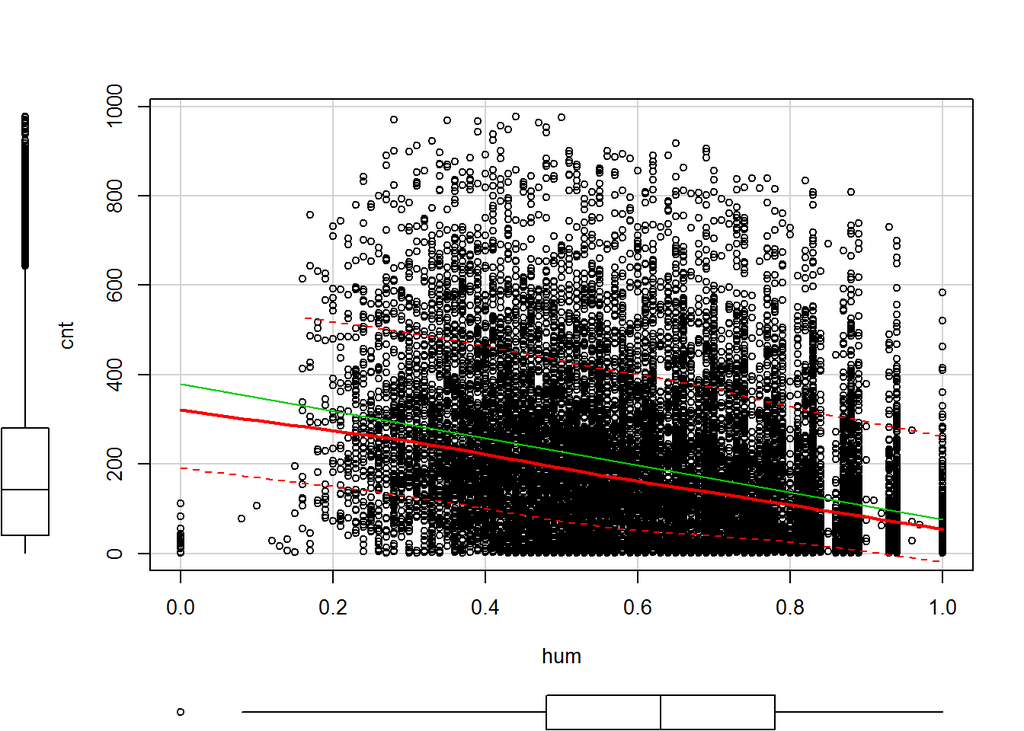

```r
scatterplot(cnt~hum,data=df)
```

# Windspeed

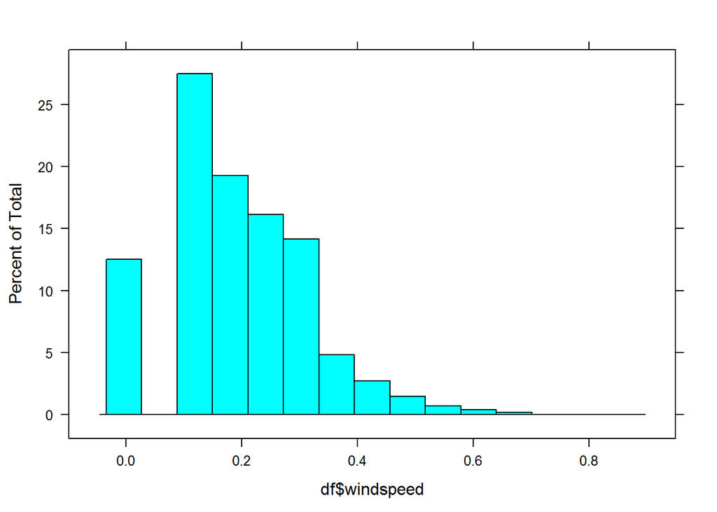

```r
histogram(df$windspeed)
```

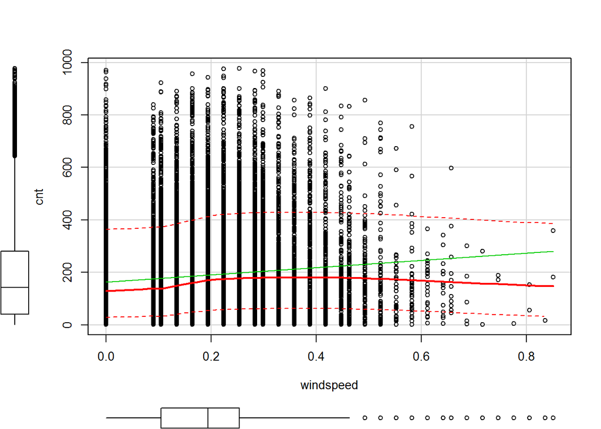

```r
scatterplot(cnt~windspeed,data=df)
```

# Correlation Analysis

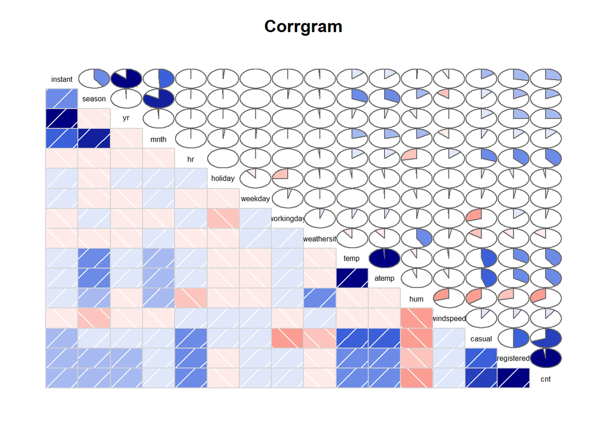

```r
corrgram(df,lower.panel=panel.shade,
         upper.panel=panel.pie, text.panel=panel.txt,
         main="Corrgram")
```

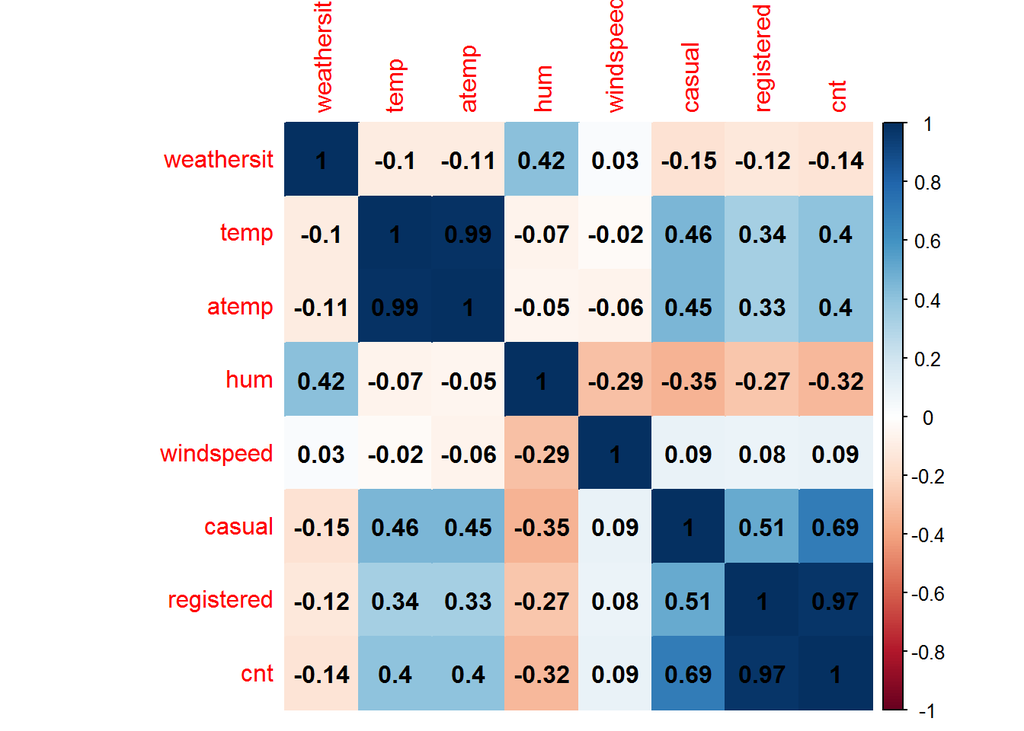

```r
df_subset <- df[,10:17]


df_cor <- cor(df_subset)
library(corrplot)
corrplot(df_cor, method = 'color', addCoef.col="black")
```

# T-TEST

```r
t.test(cnt~holiday,data=df)
```

```
##
##  Welch Two Sample t-test
##
## data:  cnt by holiday
## t = 4.6942, df = 539.61, p-value = 3.398e-06
## alternative hypothesis: true difference in means is not equal to 0
## 95 percent confidence interval:
##  19.51535 47.60181
## sample estimates:
## mean in group 0 mean in group 1
##        190.4286        156.8700
```

**It means that there is significance difference in bike sharing if the day is holiday or not**

# Regression Analysis

We are going to fit ‘cnt’ which is count of bike shared wrt to the factors: weathersit,temp,atemp,hum,windspeed,casual,registered.  
In order to test this hypothesis, we are proposing this model:  
y=b0 + b1*weathersit + b2*temp + b3*atemp + b4*hum + b5*windspeed + b6*casual + b7*registered

```r
mod1 <-lm(cnt~weathersit+temp+atemp+hum+windspeed+casual+registered,df)
summary(mod1)
```

```
##
## Call:
## lm(formula = cnt ~ weathersit + temp + atemp + hum + windspeed +
##     casual + registered, data = df)
##
## Residuals:
##        Min         1Q     Median         3Q        Max
## -3.355e-11 -7.000e-14 -3.000e-14  2.000e-14  3.864e-10
##
## Coefficients:
##               Estimate Std. Error    t value Pr(>|t|)
## (Intercept)  2.928e-12  1.286e-13  2.277e+01  < 2e-16 ***
## weathersit  -1.223e-13  4.011e-14 -3.049e+00  0.00230 **
## temp         1.561e-12  7.842e-13  1.991e+00  0.04652 *
## atemp        7.901e-13  8.811e-13  8.970e-01  0.36991
## hum         -1.816e-13  1.474e-13 -1.231e+00  0.21819
## windspeed   -5.273e-13  2.034e-13 -2.593e+00  0.00953 **
## casual       1.000e+00  5.998e-16  1.667e+15  < 2e-16 ***
## registered   1.000e+00  1.786e-16  5.600e+15  < 2e-16 ***
## ---
## Signif. codes:  0 '***' 0.001 '**' 0.01 '*' 0.05 '.' 0.1 ' ' 1
##
## Residual standard error: 3.013e-12 on 17371 degrees of freedom
## Multiple R-squared:      1,  Adjusted R-squared:      1
## F-statistic: 8.995e+30 on 7 and 17371 DF,  p-value: < 2.2e-16
```